# Changes across three Danish bird atlases: analysis plan

2026-10-20

# Purpose and scope

Describe changes in recorded breeding-bird occurrence across three atlases before analysing environmental explanations. This plan covers the four questions discussed: complete occurrence change (proposal Q1), occupancy distributions (Q2), local community change (Q4), and spatial homogenisation/heterogenisation (Q5). The separate geographical space–time model (proposal Q3) is outside this four-question plan. Analysis 1 is implemented below using observed data. Analyses 2–4 remain planned. The executable sections audit the common sample and calculate occurrence change.

Source: Carsten’s *Analysing the changes in bird distributions among the three Danish breeding bird atlases*, supplied as `Possibilities for Danish BirdAtlas Analysis of changes over time..pdf`. Examples in that proposal are simulated. Its bibliography and inferential procedures have not been independently validated here.

# One shared study sample

## Agreed cell rule

Use exactly the same cells for all three atlases and all four primary analyses. A cell must have Good or Average effort in **both Atlas 1 and Atlas 2**, have **strictly more than 25% land**, and have an identifiable occurrence row in all three atlases. Missing land or Atlas 1/2 effort values do not qualify. Atlas 3 coverage is assumed Good in every cell because no effort estimate exists; no Atlas 3 effort filter is applied. Missing observations must never be converted silently to absences.

Here, land percentage means the grid attribute `pct_lnd`, not the percentage of any particular habitat. The rule estimates change within the retained Danish grid, not automatically all of Denmark. Each retained grid cell receives equal weight; occupancy counts are not estimates of occupied habitat area.

The current `scripts/1-hmsc-prep/S0_Data_Definitions.R` maps effort codes 1 and 2 to Good and Average. Atlas 1 uses `UNDS_KODE_`; Atlas 2 uses the corrected `UNDS_KOD_1`. It uses `pct_lnd >= 25`, whereas this plan follows the requested `> 25` rule. It filters survey rows separately rather than requiring a three-atlas common grid. No effort estimate exists for Atlas 3. As agreed, assume Good coverage in all Atlas 3 cells. This is an explicit analysis assumption, not measured effort, and does not require a further coverage decision.

Do not source S0 directly: it clears the workspace, filters species for HMSC, and requires complete environmental predictors. These descriptive questions do not require environmental or trait completeness. Build the shared matrices from the occurrence table before those filters.

## Reproducible input audit

```r
suppressPackageStartupMessages({library(sf); library(readxl)})
design <- read.csv("data-new/derived/design/studyDesign.csv")
y <- read.csv("data-new/derived/occurrences/Y_occurrences.csv", check.names = FALSE)
land <- st_read(paste0("data-new/derived/atlas-grid/grids-ocean-thresholds/",
                      "grids_ocean_thresholds.shp"), quiet = TRUE)
f <- "data-new/raw/effort/dækning atlas1+2.xlsx"
e1 <- read_excel(f, sheet = "kvadrater atlas1")
e2 <- read_excel(f, sheet = "kvadrater atlas2")
stopifnot(!anyDuplicated(design$survey), !anyDuplicated(y$survey),
          !anyDuplicated(land$kvdrtkd), !anyDuplicated(e1$KVADRATKOD),
          !anyDuplicated(e2$KVADRATKOD))
good1 <- as.character(e1$KVADRATKOD[e1$UNDS_KODE_ %in% c(1, 2)])
good2 <- as.character(e2$KVADRATKOD[e2$UNDS_KOD_1 %in% c(1, 2)])
common <- Reduce(intersect, lapply(1:3, function(a) {
  as.character(design$site[design$atlas == a & design$survey %in% y$survey])
}))
effort_cells <- Reduce(intersect, list(common, good1, good2))
land_cells <- as.character(land$kvdrtkd[!is.na(land$pct_lnd) & land$pct_lnd > 25])
cells <- sort(intersect(effort_cells, land_cells))
stopifnot(length(cells) > 0)
species_columns <- setdiff(names(y), "survey")
atlases <- lapply(1:3, function(a) {
  ids <- paste(cells, a, sep = "_")
  stopifnot(all(ids %in% y$survey))
  z <- as.matrix(y[match(ids, y$survey), species_columns, drop = FALSE])
  rownames(z) <- cells
  stopifnot(!anyNA(z), all(z %in% c(0, 1)))
  z
})
names(atlases) <- paste0("Atlas", 1:3)
stopifnot(all(vapply(atlases, function(z)
  identical(dimnames(z), dimnames(atlases[[1]])), logical(1))))
knitr::kable(data.frame(
  stage = c("Rows available in all atlases", "Good/Average in both early atlases",
            "Also strictly >25% land"),
  cells = c(length(common), length(effort_cells), length(cells))))
```

| stage | cells |
| --- | --- |
| Rows available in all atlases | 2165 |
| Good/Average in both early atlases | 1959 |
| Also strictly >25% land | 1727 |

```r
knitr::kable(data.frame(
  atlas = names(atlases), cells = vapply(atlases, nrow, integer(1)),
  supplied_species = vapply(atlases, ncol, integer(1)),
  empty_rows = vapply(atlases, function(z) sum(rowSums(z) == 0), integer(1))))
```

|  | atlas | cells | supplied_species | empty_rows |
| --- | --- | --- | --- | --- |
| Atlas1 | Atlas1 | 1727 | 201 | 0 |
| Atlas2 | Atlas2 | 1727 | 201 | 0 |
| Atlas3 | Atlas3 | 1727 | 201 | 0 |

```r
cat("Species absent in all three retained matrices:",
    sum(Reduce(`+`, lapply(atlases, colSums)) == 0), "\n")
```

```
## Species absent in all three retained matrices: 0
```

Before freezing the sample, produce a cell inclusion/exclusion table with each criterion, an inclusion map (PNG), and a species inclusion table. Investigate empty rows if any occur. Atlas 3 has no additional effort requirement. If a row represents missing survey data, exclude that cell from **all** atlases and rerun the entire analysis. Do not create a different valid-cell subset for each question.

## Species and occurrence definitions: agreed

Recommended primary pool: the fixed union of taxonomically comparable breeding species recorded at least once in the final shared grid across any atlas. Retain zeros within individual atlases so that arrivals and disappearances remain visible. Species absent from the retained grid in all three atlases contribute no observed change; exclude them from the primary pool and report their names separately.

As agreed, retain all rare species: apply no minimum-occurrence threshold in any atlas. Do not inherit S0’s minimum-five-occurrences-in-every-atlas rule, which would exclude rare species, arrivals and disappearances. This decision applies throughout all four primary analyses. A fixed HMSC-compatible pool can be a secondary comparison. Do not require traits or fitted-model availability for inclusion.

Occurrence definitions and taxonomy were resolved upstream before this analysis, as confirmed by the user. Use the supplied species columns without additional taxonomic or breeding-status filtering. All rare species are retained.

# Comparisons and interpretation

Calculate Atlas 1–2, 2–3 and 1–3 using identical rows and columns. Treat 1–3 as the long-term summary and the two successive comparisons as its temporal context. They overlap and are not independent replicates. Use actual atlas survey windows in labels; verify them before converting changes to annual rates. Atlas midpoints in S0 are not a substitute for checking survey dates.

Primary inference concerns recorded occurrence. Effort filtering improves comparability but does not estimate detection probabilities or establish that all observed gains/losses are biological colonisations/extirpations.

# Analysis 1: magnitude and balance of occurrence change

For each comparison count persistent presences (a), losses (b), gains (c), and persistent absences (d) across the N by S matrix. Report:

- Total changed entries, b+c, and net recorded change, c-b.
- H = (b+c)/(NS): fraction of all entries that changed.
- J = (b+c)/(a+b+c): fraction of the temporal union that changed.
- Counts by species and by cell to identify contributions to national totals.

Check a+b+c+d=NS and c-b equals the change in total presences. H depends on the species pool and includes joint absences; report both H and J with denominators. Whole-matrix J is union-weighted across cells, not the unweighted mean local J.

Outputs: a three-comparison summary table; PNG bars for persistence, loss and gain on common scales; ranked species contributions. Keep persistent absences in the table even if omitted from the bars. No independent-entry binomial significance test.

## Definitions and denominators

Following Q1 of the proposal (pp. 2–3), a changed occurrence entry is a loss (1 to 0) or gain (0 to 1) for a particular species in a particular cell. The primary percentage is **100(b+c)/(NS)**, including persistent absences in its denominator. We also report whole-matrix Jaccard **100(b+c)/(a+b+c)**, which excludes persistent absences.

Total occupancy R is the sum of presences across the matrix (species–cell records), not the number of occupied grid cells or individual birds. Its net change is **R_later - R_earlier = c-b**. We report both **100(c-b)/R_earlier** (relative change from the earlier total) and **100(c-b)/(NS)** (percentage-point change in the fraction of entries occupied). These denominators distinguish turnover from net change and avoid confusing relative percentages with percentage points.

These are descriptive calculations for the retained sample, without independent-entry significance tests. All comparisons use the same cells and all supplied species. Occurrence definitions and taxonomy have already been resolved upstream, as confirmed by the user; no additional taxonomy or breeding-status filtering is applied here.

```r
output_dir <- file.path("manuscript-outputs", "atlas-occurrence-change")
dir.create(output_dir, recursive = TRUE, showWarnings = FALSE)
N <- nrow(atlases[[1]])
S <- ncol(atlases[[1]])
NS <- N * S
pairs <- list(c(1, 2), c(2, 3), c(1, 3))
transition_counts <- function(x, y) {
  c(persistent_presence = sum(x == 1 & y == 1),
    losses = sum(x == 1 & y == 0), gains = sum(x == 0 & y == 1),
    persistent_absence = sum(x == 0 & y == 0))
}
results <- do.call(rbind, lapply(pairs, function(k) {
  x <- atlases[[k[1]]]; y <- atlases[[k[2]]]
  counts <- transition_counts(x, y)
  a <- unname(counts[1]); b <- unname(counts[2])
  c <- unname(counts[3]); d <- unname(counts[4])
  earlier <- sum(x); later <- sum(y)
  stopifnot(sum(counts) == NS, earlier == a+b, later == a+c,
            later-earlier == c-b, sum(x != y) == b+c)
  data.frame(comparison = paste0("Atlas ", k[1], "–", k[2]),
    cells = N, species = S, entries = NS,
    persistent_presence = a, losses = b, gains = c, persistent_absence = d,
    changed_entries = b+c, changed_entries_pct = 100*(b+c)/NS,
    jaccard_pct = if (a+b+c > 0) 100*(b+c)/(a+b+c) else NA_real_,
    earlier_occupancy = earlier, later_occupancy = later,
    net_occupancy_change = c-b,
    occupancy_relative_change_pct = if (earlier > 0) 100*(c-b)/earlier else NA_real_,
    occupancy_change_pp = 100*(c-b)/NS)
}))
occupancy_totals <- data.frame(
  atlas = paste("Atlas", 1:3), cells = N, species = S, entries = NS,
  total_occupancy = vapply(atlases, sum, numeric(1)),
  occupied_entries_pct = 100*vapply(atlases, mean, numeric(1)))
# Save the exact common sample and unrounded numerical summaries.
write.csv(data.frame(site = cells, land_pct = land$pct_lnd[match(cells, land$kvdrtkd)],
  atlas1_effort_code = e1$UNDS_KODE_[match(cells, e1$KVADRATKOD)],
  atlas2_effort_code = e2$UNDS_KOD_1[match(cells, e2$KVADRATKOD)],
  atlas3_effort = "Good (assumed)"),
  file.path(output_dir, "shared-cell-manifest.csv"), row.names = FALSE)
write.csv(data.frame(species = colnames(atlases[[1]])),
          file.path(output_dir, "species-manifest.csv"), row.names = FALSE)
write.csv(results, file.path(output_dir, "pairwise-occurrence-change.csv"), row.names = FALSE)
write.csv(occupancy_totals, file.path(output_dir, "atlas-occupancy-totals.csv"), row.names = FALSE)
```

## Results

The shared sample contains **1,727 cells** and **201 species**, giving **347,127 species–cell entries** per atlas. All entries are binary and non-missing, and all three matrices have identical row and column order. No minimum-occurrence filter was applied.

Total recorded occupancy on the shared grid.

|  | Atlas | Total presences | Entries occupied (%) |
| --- | --- | --- | --- |
| Atlas1 | Atlas 1 | 93430 | 26.92 |
| Atlas2 | Atlas 2 | 106572 | 30.70 |
| Atlas3 | Atlas 3 | 111074 | 32.00 |

Gross occurrence change: losses plus gains.

| Comparison | Changed entries | Changed / all entries (%) | Changed / temporal union (%) |
| --- | --- | --- | --- |
| Atlas 1–2 | 50108 | 14.44 | 40.07 |
| Atlas 2–3 | 48328 | 13.92 | 36.34 |
| Atlas 1–3 | 58238 | 16.78 | 44.33 |

Net occupancy change: gains minus losses.

| Comparison | Net presences gained/lost | Change from earlier total (%) | Occupied entries change (pp) |
| --- | --- | --- | --- |
| Atlas 1–2 | 13142 | 14.07 | 3.79 |
| Atlas 2–3 | 4502 | 4.22 | 1.30 |
| Atlas 1–3 | 17644 | 18.88 | 5.08 |

Complete transition accounting (each row sums to the same N × S).

| Comparison | Persistent presence | Losses | Gains | Persistent absence |
| --- | --- | --- | --- | --- |
| Atlas 1–2 | 74947 | 18483 | 31625 | 222072 |
| Atlas 2–3 | 84659 | 21913 | 26415 | 214140 |
| Atlas 1–3 | 73133 | 20297 | 37941 | 215756 |

- **Atlas 1–2:** 14.44% of all occurrence entries changed (18,483 losses and 31,625 gains). Total occupancy increased by 13,142 records (+14.07% relative to the earlier total), changing the fraction of entries occupied by +3.79 percentage points.
- **Atlas 2–3:** 13.92% of all occurrence entries changed (21,913 losses and 26,415 gains). Total occupancy increased by 4,502 records (+4.22% relative to the earlier total), changing the fraction of entries occupied by +1.30 percentage points.
- **Atlas 1–3:** 16.78% of all occurrence entries changed (20,297 losses and 37,941 gains). Total occupancy increased by 17,644 records (+18.88% relative to the earlier total), changing the fraction of entries occupied by +5.08 percentage points.

Gross change counts both gains and losses; net occupancy change allows them to cancel. Their difference shows how much rearrangement is hidden by the change in total presences. These are changes in recorded distributions within the shared sample, not estimates of bird abundance change.

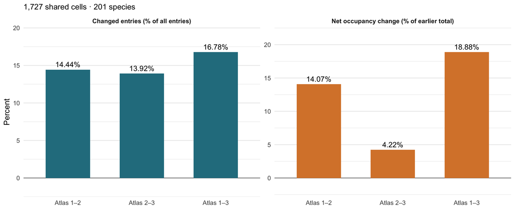

Gross occurrence change and net occupancy change for the same cells and species. Panel denominators differ and are labelled explicitly.

# Analysis 2: occupancy distribution and species-specific range changes

For every species and atlas calculate occupied-cell count r and occupancy p=r/N. Use the same N and species list everywhere. Produce:

1. Identical-bin histograms, explicitly separating zero occupancy.
2. Overlaid empirical cumulative distributions (ECDFs).
3. Species-matched scatterplots for each comparison, with equality lines.
4. A species table of counts, signed changes and gains/losses, highlighting the largest expansions/contractions and changes to/from zero.

Summarise medians, 10th/90th percentiles, zeros and occupancy classes (proposed reporting bins: 0, >0–10%, >10–50%, >50%; these are not ecological thresholds). Report Wasserstein-1 distance W1=mean(abs(sort(p_later)-sort(p_earlier))), mean signed species change, and mean absolute matched change M.

Check W1 <= M <= H. W1 measures distributional change without retaining species identity; M retains identity but not geography. Mean occupancy and mean cell richness are algebraically related, not independent evidence. Report proportional differences in percentage points, alongside raw occupied-cell counts.

Primary analysis is descriptive. Do not add an independent-sample KS test or interpret a non-significant test as distributional stability. A formal repeated-distribution test or equivalence claim would require a separate inferential target and calibration. Use alternative histogram bins and a presence-only distribution as labelled sensitivities.

# Analysis 3: local community change and departures from a null

## Observed change

For each cell and comparison calculate a_i, b_i, c_i, raw richness change c_i-b_i, and temporal Jaccard TBI_i=(b_i+c_i)/(a_i+b_i+c_i). Split TBI into loss contribution b_i/union and gain contribution c_i/union. These sum to TBI and preserve direction.

Outputs: PNG maps of TBI, raw losses, raw gains and net richness change, with consistent scales across comparisons; distributions and a cell-level result table. A high proportion in a species-poor cell can reflect only a few changes, so retain raw counts. Optional replacement/nestedness partitions answer a different question and should not be labelled loss/gain components.

## Conditional allocation model

For each species and atlas pair, fix the earlier map and observed numbers of losses and gains. Allocate losses among earlier occupied cells and gains among earlier unoccupied cells. Repeat and compute local TBI each time.

This asks whether local change is unusually concentrated **given national species transition totals**. It preserves endpoint occupancies and species transition counts, but not later cell richness, spatial clustering or dependence among species’ changes. It does not test whether national change occurred or identify environmental drivers.

The major unresolved choice is which locations are eligible for exchange: unrestricted national allocation is a transparent benchmark; regional allocation conditions additionally on regional transitions. Define regions independently of the observed changes, inspect eligible-cell counts, and examine sensitivity. Spatial blocks for uncertainty estimation are a separate choice from these allocation strata.

Report observed TBI, mean expected TBI and observed-minus-expected TBI. For inferential maps, also use each full null distribution and explicitly choose multiplicity control. Holm across all cells and three comparisons controls familywise error if individual p-values are valid, but can require very large simulation counts. With m tests, at least ceiling(m/0.05)-1 simulations are needed merely for the minimum plus-one p-value to reach the first 5% Holm threshold. This is not a precision recommendation. FDR requires a justified procedure for the dependence structure. Continuous excess maps can be reported without declaring cells significant.

Run a small pilot for correctness and runtime; choose final repetitions from the required tail resolution and Monte Carlo precision. Save seed, constraints and simulation settings. Each pair’s null is separate, not a coherent joint three-atlas simulation.

# Analysis 4: homogenisation or heterogenisation among cells

Within each atlas, calculate Jaccard dissimilarity for all unordered distinct cell pairs and take their equal-weight mean beta. For each temporal comparison calculate Delta_beta = beta_later-beta_earlier. Negative values indicate observed homogenisation; positive values indicate heterogenisation.

Outputs: a table and PNG of atlas means and signed differences; use the same spatial extent, species pool and cell-pair weighting in all atlases. Do not treat the N(N-1)/2 distances as independent observations.

Use the same conditional allocation model as Analysis 3 to calculate the null distribution of Delta_beta. This assesses the spatial arrangement of gains and losses conditional on national transitions. Report the observed sign separately from its position in the null distribution. A positive change below the null expectation is less heterogenisation than expected, not observed homogenisation.

Pre-specify a two-sided departure test unless there is a directional hypothesis chosen before inspecting results; define the family of three global comparisons. The null does not preserve individual cell richness. Fixing both row totals and species transition totals would require a separately validated constrained sampler.

A national all-pairs average mixes spatial distances. Recommended secondary analysis: repeat within pre-defined distance bands or neighbourhoods, fixed across atlases, to distinguish nearby from broad-scale change. Choose distances from ecological scale and grid geometry, not from the most striking result. Optional replacement/nestedness partitions may explain which component changes.

For computational efficiency, calculate the observed all-pairs statistic exactly in chunks if needed. Do not recompute an expensive national distance matrix for every replicate used only to refine local p-values. Use a separate, adequate global simulation budget from the same null model; if sampling pairs, fix the pair sample across atlases and replicates and quantify approximation error.

# Cross-cutting choices and proposed defaults

| Choice | Proposed primary treatment | Status |
| --- | --- | --- |
| Shared cells | Good/Average in both early atlases, >25% land, rows in all three | User specified; audit passed |
| Atlas 3 effort | Assume Good in all cells; no effort estimate exists | User specified |
| Species pool | Fixed union observed in retained cells; retain period-specific zeros | Upstream definitions accepted; rare species retained |
| Minimum occurrences | Retain all rare species; no minimum threshold in any atlas | User specified |
| Missing values | Never interpret as zero; resolve and freeze one common mask | Required |
| Genuine empty communities | Investigate first; if real, explicitly define double-empty Jaccard | Unresolved if present |
| Weighting | Equal cells, equal species contributions as defined, equal distinct cell pairs | Recommended |
| Atlas contrasts | All three; long-term summary plus successive intervals | Recommended |
| Allocation null | Fixed baseline and species gains/losses; compare national and justified regional constraints | Region choice pending |
| Local significance | Excess maps primary; corrected tests only with defensible null and adequate precision | Decision pending |
| Global null comparisons | Two-sided unless pre-specified directional hypothesis; adjust three comparisons | Recommended |
| Confidence intervals | Only with explicit spatial-process target and checked block design | Optional, separate from allocation null |
| Sensitivities | Good-only shared grid; species pool; bins; null strata; spatial scale | Recompute all relevant contrasts consistently |
| Figures | PNG only | User specified |

A fixed set of recorded atlas entries has directly calculable descriptive statistics. Confidence intervals require a target beyond those fixed entries. If spatial-process uncertainty is wanted, resample entire spatial blocks carrying all species and all three atlas histories together. Inspect spatial dependence and regional variation, choose several defensible block sizes/layouts, and assess coverage before interpreting intervals. Such intervals do not correct detection error. Do not bootstrap the list of pairwise distances or independently resample each atlas.

For a genuine pair of empty communities, Jaccard’s denominator is zero. Possible policy: assign zero dissimilarity, explicitly treating joint absence as similarity, and check sensitivity. For one empty and one nonempty community Jaccard is one. Apply any chosen policy to observations and all simulations; never silently drop undefined replicates. If emptiness represents missing coverage, fix the common sample instead.

# Work sequence and completion checks

1. Use the upstream occurrence definitions and taxonomy, retaining all rare species and assuming Good Atlas 3 coverage. The shared cell and species manifests are saved by Analysis 1; the current sample has no empty or missing rows.
2. Build aligned binary matrices and validate identifiers, dimensions and counts.
3. Complete all four descriptive analyses and inspect species/cell contributors.
4. Agree allocation strata and inferential claims; pilot null simulations and check preserved transition totals exactly.
5. Run appropriately sized null analyses, multiplicity control and selected sensitivities. Add spatial-process intervals only if justified and useful.
6. Write results around effect sizes, directions, species and places. Link patterns to subsequent environmental analyses without claiming causation here.

The final R Markdown should retain the explanations above beside executable sections, load saved expensive simulations rather than rerunning them on every knit, record session information and seeds, and produce tables plus PNG figures. Every sensitivity uses its own explicitly labelled fixed sample across all three atlases; it does not silently change the primary grid.